# Mt Victoria Vermin Trappers Report

Trap line: Telford

Report created by: Ben Anderson

Last run: 2025-03-15

# 1 Code

The code used to produce this report is [open source](https://github.com/dataknut/trap.nz) under an [Apache 2.0 license](https://github.com/dataknut/trap.nz?tab=Apache-2.0-1-ov-file#readme). Feel free to contribute. Or fork & go.

# 2 Introduction

This is a simple report of trapping activity and outcomes for the Mt Victoria Vermin Trappers’ **Telford** trap line which covers the northern part of Wellington’s Southern Walkway between Roseneath Park & Lookout and Mount Victoria Lookout. It uses the latest ‘complete trapline’ records since 2017-03-06 downloaded from trap.nz at 2025-03-15 16:47:08.016341.

Table 2.1: Trap types

| trap type | N |
| --- | --- |
| A24 | 2 |
| DOC 200 | 6 |
| Victor | 26 |

# 3 Trap checking frequency

Figure 3.1 shows the frequency of records for each trap by month since the start of trapping. Normally we would hope there to be at least 2 checks per month. There are some clear gaps which will affect any subsequent ‘trend’ analysis.

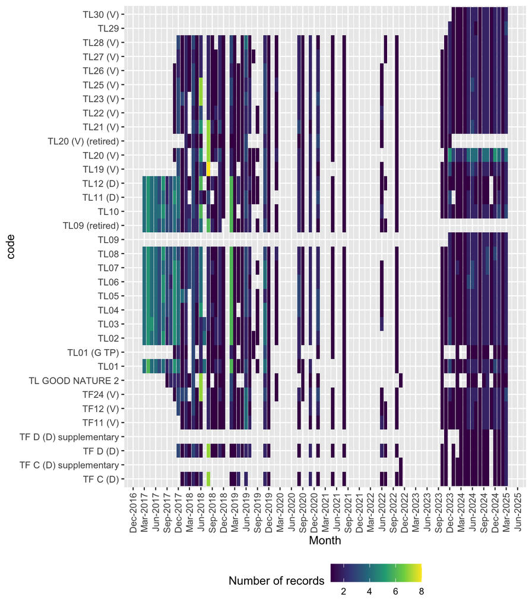

Figure 3.1: Trap checking frequency over time

# 4 Species caught

The species caught since the beginning of the monitoring dataset (2017-03-06) are shown in Figure 4.1. Note that this does not (cannot) include any species killed by the A24 traps (or indeed any other traps) which have then been eaten as carrion or otherwise removed before the trap has been re-checked.

In addition the frequency of checking (see Figure 3.1) is likely to affect the frequency of species capture since ‘full’ traps are unlikely to attract further kills until cleared.

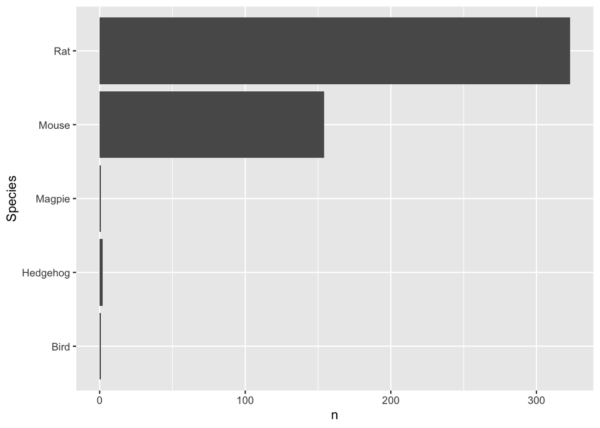

Figure 4.1: Species recorded

Figure 4.2 shows the frequency of capture of different recorded species per month with additional smoothed fit lines for each species where sufficient data exists.

This plot appears to be particularly affected by the frequency of checking patterns shown in Figure 3.1. However if we compare periods of relatively frequent checking it appears that the frequency of rat capture is lower in early 2024 than in (e.g.) early 2020. However it also appears that the frequency of mouse capture has increased.

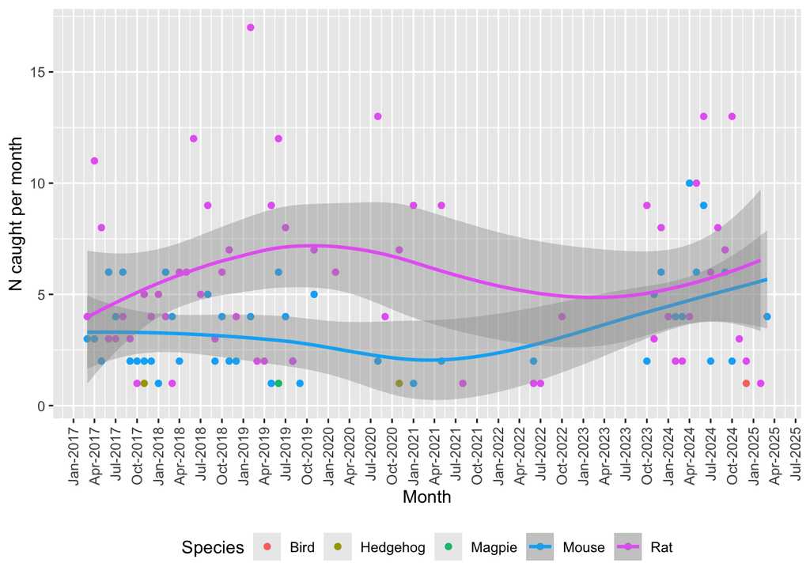

Figure 4.2: Frequency of species caught per month

Figure 4.3 repeats this plot but includes the total number of traps recording no species caught per month.

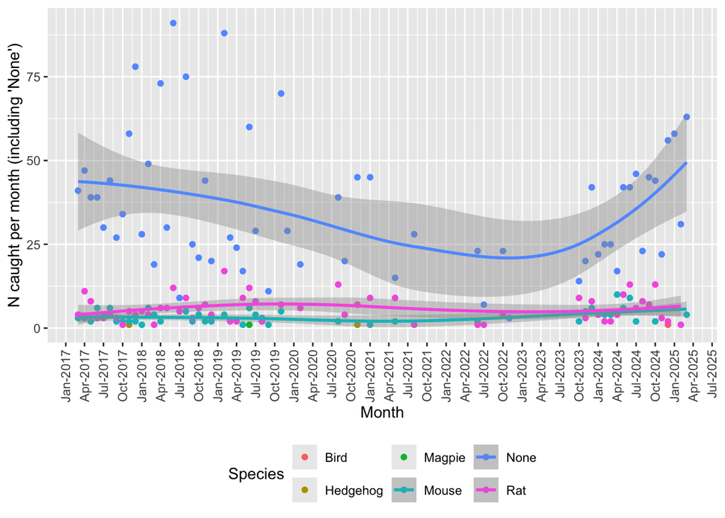

Figure 4.3: Frequency of species caught per month - including None

Figure 4.4 re-plots this data as a ‘rate’ by dividing by the number of clearing ‘events’ (i.e. someone recorded clearing the line) per month and the number of traps checked. This assumes each clearance took one day which is not necessarily true.

Note that this may also produce some strange outliers if a very small number of traps are checked and each have a species recorded.

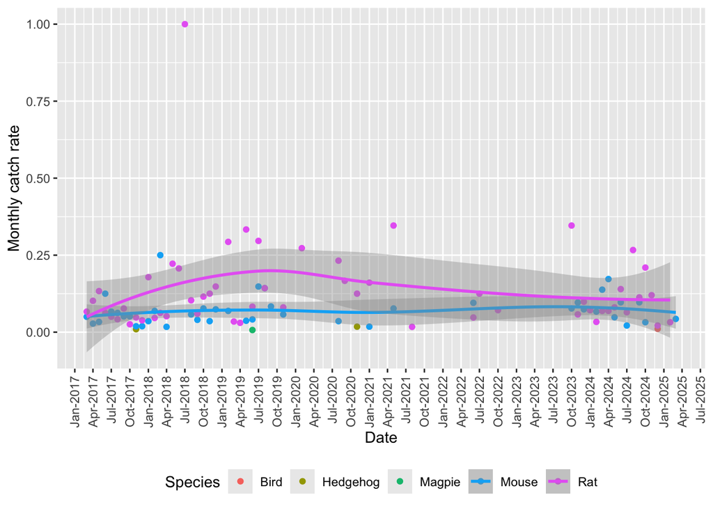

Figure 4.4: Rate of species caught per month/trap/clearance events

# 5 Seasonal analysis

Do we find a monthly/seasonal pattern? The first plot uses the aggregated frequency rather than the rate.

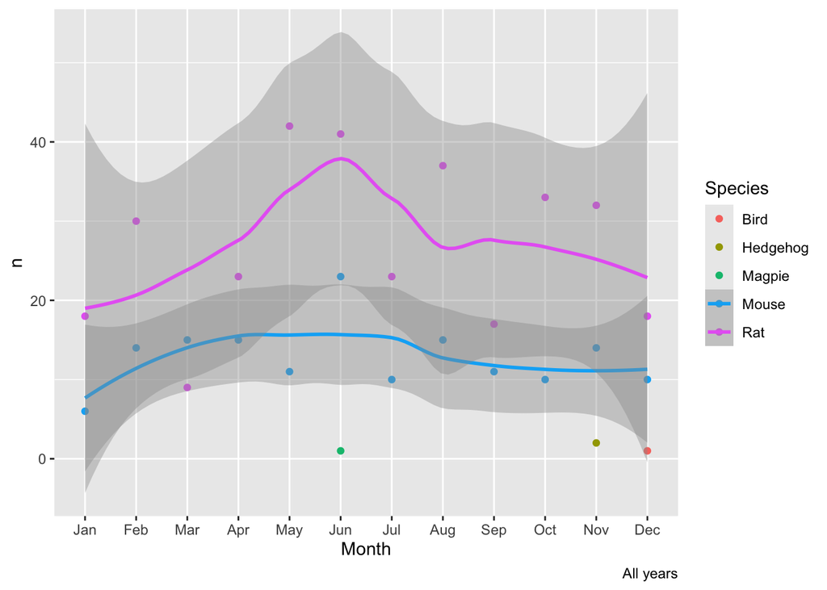

Figure 5.1: Species recorded by month

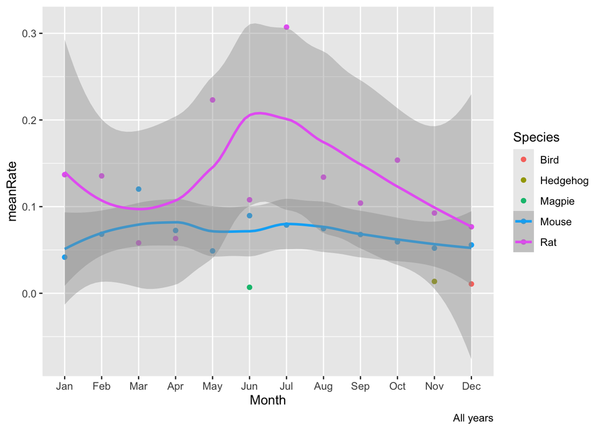

Figure 5.2: Species recorded by month

# 6 Summary